# Red Wine Quality Exploration by Kartik Garg

# Multivariate Plots Section

### Alcohol and other variables

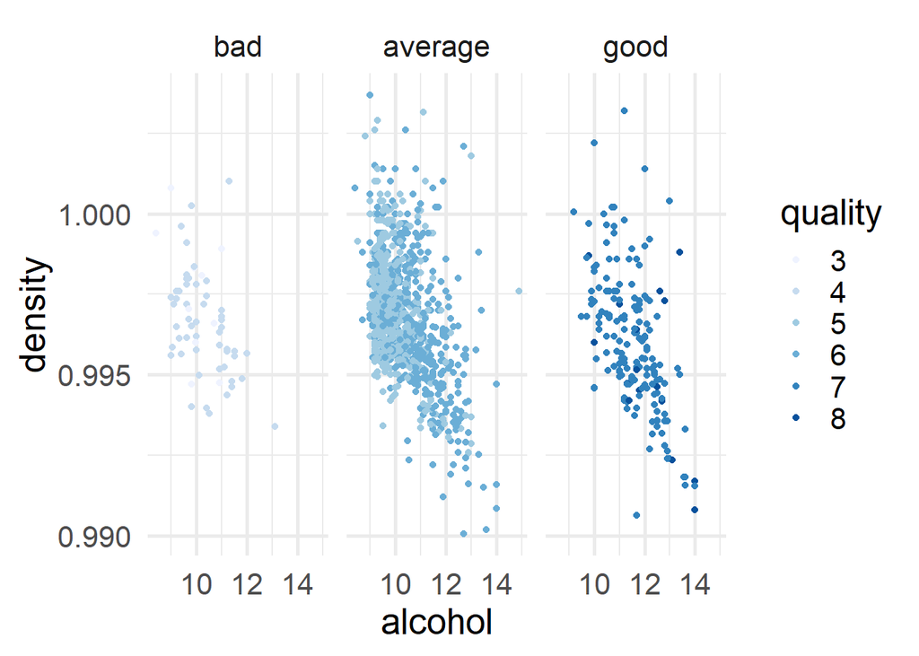

When we hold alcohol constant, there is no evidence that density affects quality.

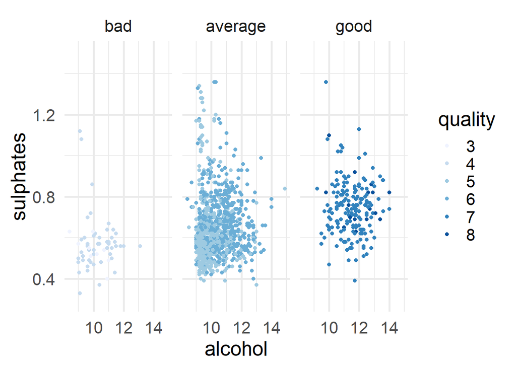

For wines with high alcohol content, having a higher concentration of sulphates produces better wines.

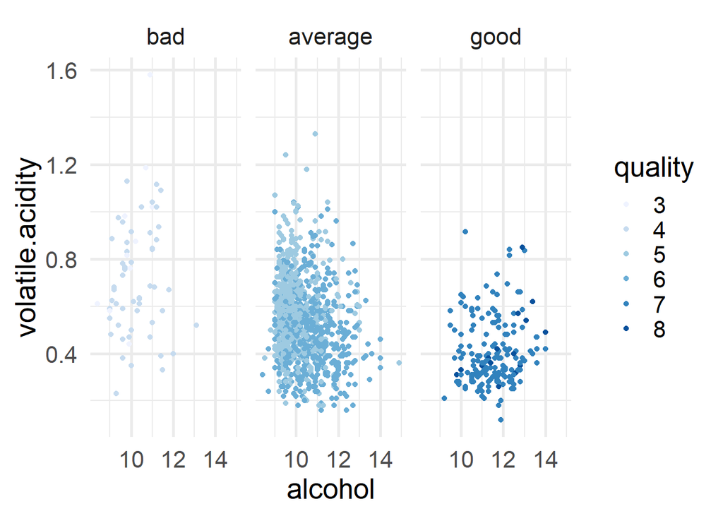

Having less acetic acid on higher concentration of alcohol seems to produce better wines.

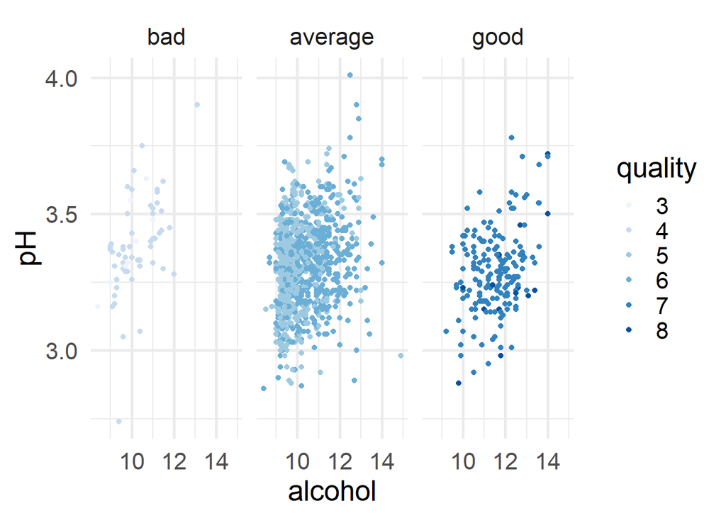

Low pH and high alcohol concentration seem to be a good match.

### Acid exploration

*The relationship between the acids and quality.*

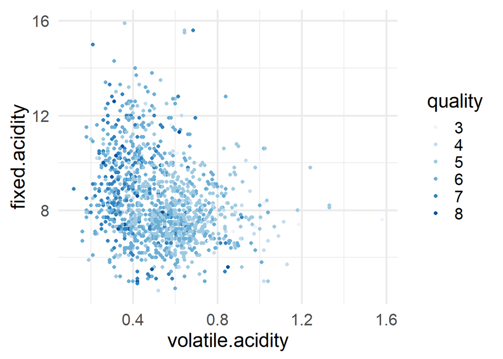

Almost no variance in the y axis compared to the x axis. Lets try the other acids.

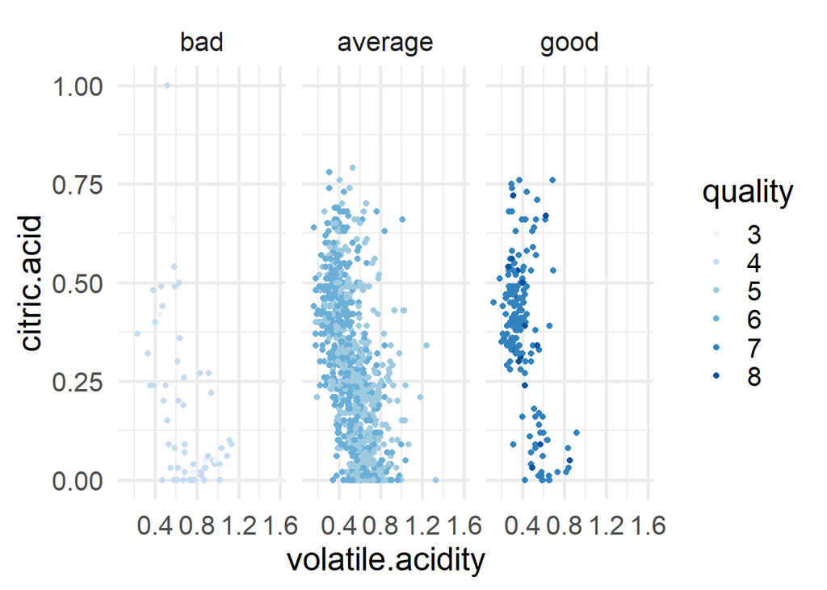

High citric acid and low acetic acid seems like a good combination.

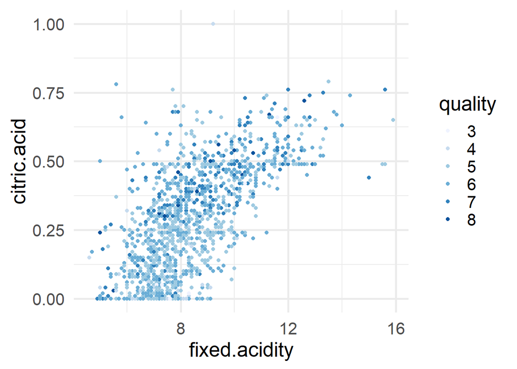

```
##
##  Pearson's product-moment correlation
##
## data:  redwine$citric.acid and redwine$fixed.acidity
## t = 36.234, df = 1597, p-value < 2.2e-16
## alternative hypothesis: true correlation is not equal to 0
## 95 percent confidence interval:
##  0.6438839 0.6977493
## sample estimates:
##       cor
## 0.6717034
```

do not get much correlation with the quality here.

### Linear model

To generate some linear models and compare them most prominent variables are used .

```
##
## Calls:
## m1: lm(formula = as.numeric(quality) ~ alcohol, data = training_data)
## m2: lm(formula = as.numeric(quality) ~ alcohol + sulphates, data = training_data)
## m3: lm(formula = as.numeric(quality) ~ alcohol + sulphates + volatile.acidity,
##     data = training_data)
## m4: lm(formula = as.numeric(quality) ~ alcohol + sulphates + volatile.acidity +
##     citric.acid, data = training_data)
## m5: lm(formula = as.numeric(quality) ~ alcohol + sulphates + volatile.acidity +
##     citric.acid + fixed.acidity, data = training_data)
## m6: lm(formula = as.numeric(quality) ~ alcohol + sulphates + pH,
##     data = training_data)
##
## ===================================================================================================
##                          m1           m2           m3           m4           m5           m6
## ---------------------------------------------------------------------------------------------------
##   (Intercept)          -0.066       -0.604**      0.605*       0.670**      0.294        1.328*
##                        (0.220)      (0.224)      (0.248)      (0.257)      (0.289)      (0.516)
##   alcohol               0.357***     0.339***     0.306***     0.305***     0.315***     0.362***
##                        (0.021)      (0.020)      (0.020)      (0.020)      (0.020)      (0.021)
##   sulphates                          1.099***     0.745***     0.770***     0.780***     0.980***
##                                     (0.138)      (0.137)      (0.139)      (0.138)      (0.139)
##   volatile.acidity                               -1.199***    -1.272***    -1.333***
##                                                  (0.125)      (0.146)      (0.147)
##   citric.acid                                                 -0.128       -0.436*
##                                                               (0.130)      (0.170)
##   fixed.acidity                                                             0.047**
##                                                                            (0.017)
##   pH                                                                                    -0.631***
##                                                                                         (0.152)
## ---------------------------------------------------------------------------------------------------
##   R-squared             0.232        0.280        0.343        0.344        0.349        0.293
##   adj. R-squared        0.231        0.279        0.341        0.341        0.346        0.291
##   sigma                 0.704        0.682        0.651        0.651        0.649        0.676
##   F                   289.048      185.949      166.182      124.873      102.212      131.779
##   p                     0.000        0.000        0.000        0.000        0.000        0.000
##   Log-likelihood    -1022.548     -991.540     -947.687     -947.203     -943.227     -983.004
##   Deviance            473.685      444.023      405.216      404.808      401.465      436.188
##   AIC                2051.096     1991.080     1905.374     1906.407     1900.454     1976.008
##   BIC                2065.693     2010.544     1929.704     1935.602     1934.516     2000.337
##   N                   959          959          959          959          959          959
## ===================================================================================================
```

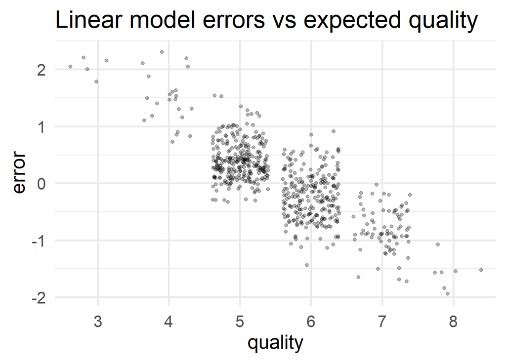

# Multivariate Analysis

High alcohol contents and high sulphate concentrations combined seem to produce better wines.

### Were there any interesting or surprising interactions between features?

No such interesting or surprising interactions between features were found apat from the previous one.

Yes, linear model is created, But the main problem was there was not enough statistic to have a significant confidence level in the equations produced. This can be due to the fact that our dataset comprised mainly of ‘Average’ quality wines and as there were very few data about the ‘Good’ and the ‘Bad’ quality wines in the training dataset, thatis why it was difficult to predict statistics for the edge cases. Maybe a more complete dataset would have helped me better in predicting the higher range values.

# Final Plots and Summary

### Plot One

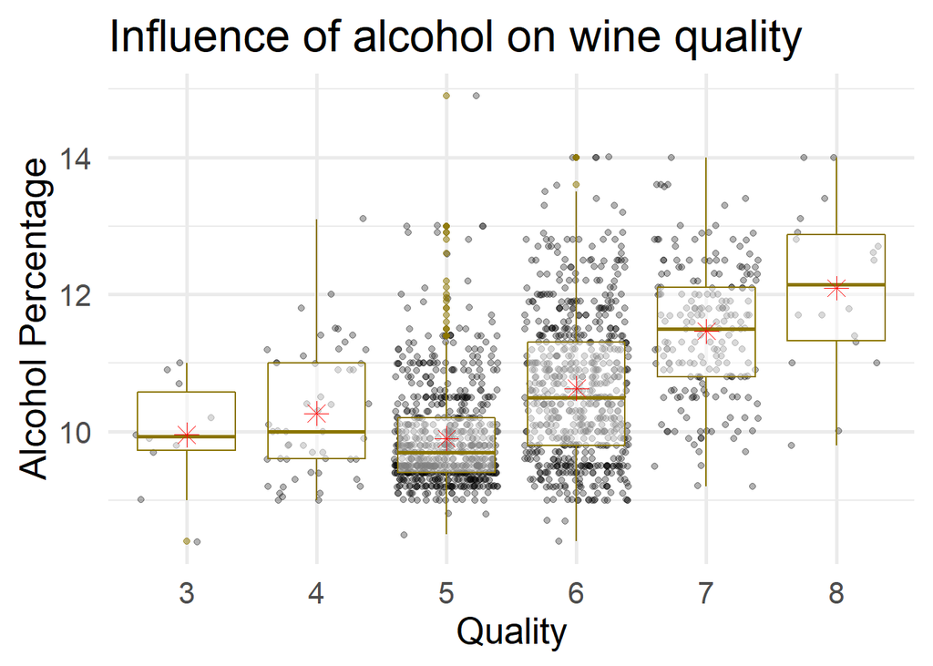

### Plot Two

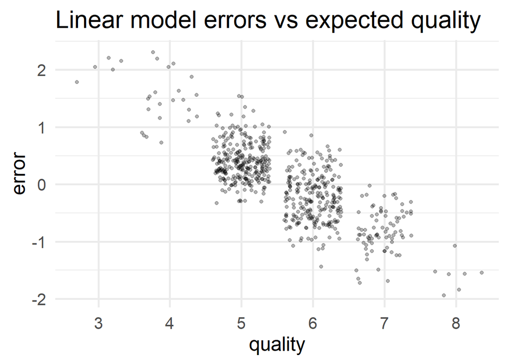

### Plot Three

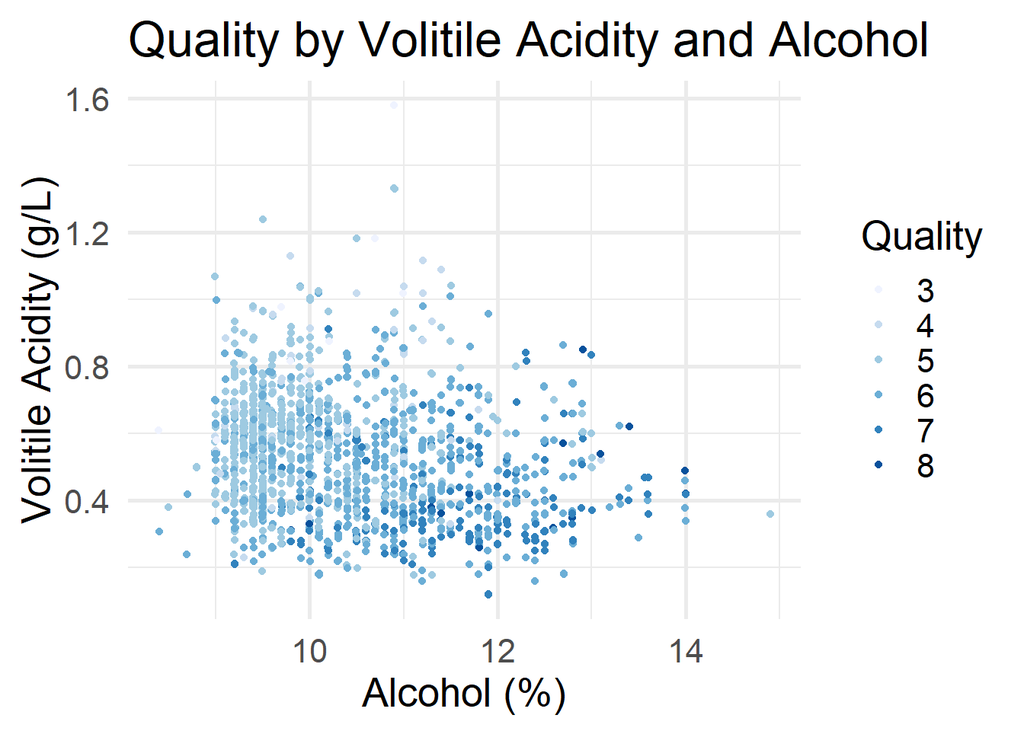

```r
ggplot(redwine, aes(x = alcohol, y = volatile.acidity, color = factor(quality))) +
  geom_jitter() +
  scale_color_brewer(name = "Quality") +
  ggtitle("Quality by Volitile Acidity and Alcohol") +
  xlab("Alcohol (%)") +
  ylab("Volitile Acidity (g/L)")
```

### Description Three

This chart shows how quality improves as the alcohol content increases and the volitile acidity decreases. There is an overall trend of the colors getting darker as they go to the bottom right.

# Reflection

### Struggle

My main struggle was to get a higher confidence level when predicting factors that are responsible for the production of different quality of wines especially the ‘Good’ and the ‘Bad’ ones.

### Surprising

Among all the chemical variable, I saw that some wines did not have citric acid at all. My first thought was maybe there is an error in collecting data. But then I researched further about wines and found that citric acid actually is added to some wines to increase the acidity. So it is evident that some wines would not have Citric Acid at all.

The first surprise here was the correlation between acetic acid concentration and pH was positive. I immediately suspected this was due to Simpsons paradox and with the help of the “Simpsons” package I confirmed that suspicion. Second the concentration of the three acids only account for less than half of the variance in pH. I interpreted this as a sign that there are more components affecting acidity that were not measured.

### Findings

All the other variables part from citric acid showed either a normal or a long tailed looking distribution. The most promissing varibles were alcohol concentration, sulphates and the individual acid concentrations. On the final part of the analysis I tried using multivariate plots to investigate if there were interesting combinations of variables that might affect quality. I also used a multivariate plot to confirm that density did not have an effect on quality when holding alcohol concentration constant.

### Future work

I would love to have a dataset, where apart from the wine quality, a rank is given for that particular wine by 5 different wine  
tasters as we know when we include the human element, our opinion changes on so many different factors. So by including the human  
element I would be able to put in that perspective and see a lot of unseen factors which might result in a better or worse wine quality.